# backtesting_debug

### Objective

This project is part of the Quantitative Finance Executive Program (QUANt) at CEMA University in Argentina. As running all the transformations takes several hours only the following were run in this notebook: return, risk, sharpe_ratio, information_ratio, sortino_ratio and calmar_ratio.

### Data Types

- Opening price
- Close price
- Maximum price
- Minimum price
- Adjusted close price

### Types of Segmentation

- **Dynamic:** Statistics of time windows within a period.
  - K-means clustering of statistics correlation matrix (nClusters = 10)
  - K-means clustering of statistics covariance matrix (nClusters = 10)
  - K-means clustering of statistics matrix (nClusters = 10)
- **Static:** Whole period statistics.
  - Statistics deciles (equiprobable)
  - Same distance (equidistant)

### Segment Selection Methods

- **Lower bound:** Minimum proportion of stocks, among all, to be considered within the segment.
- **Upper bound:** Maximum proportion of stocks, among all, to be considered within the segment.
- **Min:** Select the first segment sorted in ascending order, meaning the segment with the lowest average statistic value is selected for investment.
- **Max:** Select the first segment sorted in descending order, meaning the segment with the highest average statistic value is selected for investment.

### Statistics to Segment

- **Return**:  
  $\bar{R} = \frac{1}{n} \sum_{i=1}^{n} R_i$  
  Where $R_i$ represents the return at time $i$, and $n$ is the number of observations.
- **Risk**:  
  ${\sigma_R} = \sqrt{\frac{1}{n} \sum_{i=1}^{n} \left(R_i - \bar{R}\right)^2}$  
  Where $R_i$ is the return at time $i$, and $\bar{R}$ is the average return.
- **Bias**:  
  $\frac{\sum (X_i - \bar{X})^3}{(N - 1) \cdot \sigma^3}$  
  Where $X_i$ represents individual data points, $\bar{X}$ is the mean of $X$, $N$ is the number of observations, and $\sigma$ is the standard deviation of $X$.
- **Kurtosis**:  
  $\frac{\sum (X_i - \bar{X})^4}{N \cdot \sigma^4}$  
  Where $X_i$ represents individual data points, $\bar{X}$ is the mean of $X$, $N$ is the number of observations, and $\sigma$ is the standard deviation of $X$.
- **Beta**:  
  ${\beta} = \frac{\text{Cov}(R_i, R_m)}{\text{Var}(R_m)}$  
  Where $\text{Cov}(R_i, R_m)$ is the covariance between the return of the asset ($R_i$) and the market return ($R_m$), and $\text{Var}(R_m)$ is the variance of the market return.
- **Sharpe Ratio**:  
  $\frac{\bar{R}}{\sigma_R}$  
  Where $\bar{R}$ is the average return and $\sigma_R$ is the standard deviation of returns.
- **Information Ratio**:  
  $\frac{R_p - R_f}{\sigma_{p - b}}$  
  Where $R_p$ is the average return of the portfolio, $R_f$ is the risk-free rate, and $\sigma_{p - b}$ is the standard deviation of the difference between the portfolio return and the benchmark return.
- **Burke Ratio**:  
  $\frac{\bar{R}}{\sqrt{\sum_{\text{Drawdown}^{2}}}}$  
  Where $\bar{R}$ is the average return, and $\sqrt{\sum_{\text{Drawdown}^{2}}}$ is the square root of the sum of the squared drawdowns.
- **Sortino Ratio**:  
  $\frac{\bar{R}}{\sigma_d}$  
  Where $\bar{R}$ is the average return and $\sigma_d$ is the standard deviation of negative returns.
- **Calmar Ratio**:  
  $\frac{\bar{R}}{\text{Drawdown}_{\text{max}}}$  
  Where $\bar{R}$ is the average return and $\text{Drawdown}_{\text{max}}$ is the maximum drawdown.

# Libraries

```python
# Data manipulation
import numpy as np
import pandas as pd
import datetime as dt
from pandas import ExcelWriter

# Financial data
import yfinance as yf

# Statistics and clustering
from scipy.stats import skew, kurtosis
from sklearn.cluster import KMeans

# Visualization
import seaborn as sns
import matplotlib.pyplot as plt
from prettytable import PrettyTable

# Utilities
from tqdm import tqdm
from itertools import product
import os, warnings

warnings.filterwarnings("ignore")
```

# S&P 500 Index

```python
class SnP_500_index:
    """
    The objective of this class is to download the prices of the S&P500 index and store them in an Excel file if desired.

    Parameters
    ----------
    time : int, optional
        The number of years to go back in time from today to download the S&P500 index data.
        Default is 5 years.
    """

    def __init__(self, time: int = 5):
        assert isinstance(time, int), "The variable 'time' must be an integer."

        self.years = time  # years to go back in time
        self.since = dt.datetime.now() - dt.timedelta(days=365 * self.years)  # start date
        self.until = dt.datetime.now()  # end date

        self.snp500index = pd.Series(dtype='float64')

    def download_snp500_index(self) -> pd.Series:
        """
        Downloads the S&P500 index data and stores it in a variable.

        Returns
        -------
        pd.Series
            A pandas Series containing the closing prices of the S&P500 index from the start date until today.
        """

        self.snp500index = yf.download('^GSPC', start=self.since, end=self.until, progress=False)['Close']
        return self.snp500index

    def save_snp500_index(self, route: str = None) -> None:
        """
        Stores the S&P500 index data in an Excel file.

        Parameters
        ----------
        route : str, optional
            The directory where you want to store the Excel file.
            If not provided, it will store the file in the current working directory.
        """

        if route is None:
            route = os.getcwd() + '/'
        else:
            assert isinstance(route, str), "The 'route' variable must be a string"

        self.snp500index.to_excel(f'{route}snp500indexData.xlsx')

snp_index = SnP_500_index()
snp_data = snp_index.download_snp500_index()
display(snp_data.head())
```

```
Date
2019-09-23    2991.780029
2019-09-24    2966.600098
2019-09-25    2984.870117
2019-09-26    2977.620117
2019-09-27    2961.790039
Name: Close, dtype: float64
```

# S&P 500 Tickers

```python
class SnP_500_data:
    """
    The objective of this class is to download the prices of the stocks listed in the S&P500 index and store them in an Excel file if desired.

    Parameters
    ----------
    time : int, optional
        The number of years to go back in time from today to download the stock data for S&P500 companies.
        Default is 5 years.
    """

    def __init__(self, time: int = 5):
        assert isinstance(time, int), "The variable 'time' must be an integer."

        self.types_data = ['Open', 'Close', 'Low', 'High', 'Adj Close']  # type of prices
        self.years = time  # years to go back in time
        self.since = dt.datetime.now() - dt.timedelta(days=365 * self.years)  # start date
        self.until = dt.datetime.now()  # end date

        self.tickers = pd.Series(dtype='str')
        self.stock_data = {}
        self.stock_data_ = {}

    def download_snp500_data(self) -> dict:
        """
        Downloads the stock data for all companies in the S&P500 index and stores it in a dictionary.

        Returns
        -------
        dict
            A dictionary where each key corresponds to a type of price data ('Open', 'Close', 'Low', 'High', 'Adj Close') and
            each value is a DataFrame with the tickers as columns and dates as rows.
        """

        to_replace = {'BRK.B': 'BRK-B', 'BF.B': 'BF-B'}
        self.tickers = pd.read_html('https://en.wikipedia.org/wiki/List_of_S%26P_500_companies')[0]['Symbol']
        self.tickers.replace(to_replace, inplace=True)
        self.tickers = self.tickers.unique()

        self.stock_data = {}
        for tick in tqdm(self.tickers):
            self.stock_data[tick] = yf.download(tick, start=self.since, end=self.until, progress=False)

        self.stock_data_ = {metricdata: pd.DataFrame() for metricdata in self.types_data}
        for type_data in self.types_data:
            for tick in self.tickers:
                self.stock_data_[type_data][tick] = self.stock_data[tick][type_data]

        return self.stock_data_

    def save_snp500_data(self, route: str = None) -> None:
        """
        Stores the downloaded stock data in an Excel file.

        Parameters
        ----------
        route : str, optional
            The directory where you want to store the Excel file.
            If not provided, it will store the file in the current working directory.
        """

        if route is None:
            route = os.getcwd() + '/'
        else:
            assert isinstance(route, str), "The 'route' variable must be a string"

        with ExcelWriter(f'{route}snp500tickersData.xlsx', engine='xlsxwriter') as writer:
            for key in self.stock_data_.keys():
                self.stock_data_[key].to_excel(writer, sheet_name=key)

snp_tickers = SnP_500_data()  # Crear la instancia de la clase
tickers_data = snp_tickers.download_snp500_data()  # Descargar los datos
display(tickers_data[list(tickers_data.keys())[0]].head())
```

| Date | MMM | AOS | ABT | ABBV | ACN | ADBE | AMD | AES | AFL | A | ... | WY | WMB | WTW | WYNN | XEL | XYL | YUM | ZBRA | ZBH | ZTS |
| --- | --- | --- | --- | --- | --- | --- | --- | --- | --- | --- | --- | --- | --- | --- | --- | --- | --- | --- | --- | --- | --- |
| 2019-09-23 | 138.369568 | 47.000000 | 83.430000 | 72.330002 | 192.330002 | 275.929993 | 30.120001 | 16.080000 | 51.740002 | 77.480003 | ... | 27.410000 | 24.600000 | 195.419998 | 107.139999 | 64.809998 | 77.019997 | 112.000000 | 202.759995 | 137.300964 | 125.349998 |
| 2019-09-24 | 139.673920 | 47.950001 | 83.660004 | 73.830002 | 194.440002 | 279.579987 | 30.540001 | 16.299999 | 52.380001 | 78.290001 | ... | 27.690001 | 24.580000 | 198.139999 | 111.809998 | 64.940002 | 77.970001 | 114.370003 | 205.860001 | 138.097092 | 125.480003 |
| 2019-09-25 | 137.759201 | 47.369999 | 82.400002 | 72.879997 | 191.600006 | 271.899994 | 29.480000 | 16.139999 | 52.250000 | 76.050003 | ... | 27.540001 | 24.200001 | 196.800003 | 109.370003 | 65.349998 | 76.809998 | 112.160004 | 203.589996 | 136.038834 | 124.650002 |
| 2019-09-26 | 137.123749 | 47.820000 | 83.279999 | 72.949997 | 188.059998 | 278.459991 | 29.670000 | 16.190001 | 52.240002 | 76.449997 | ... | 27.910000 | 24.320000 | 196.410004 | 110.500000 | 65.379997 | 78.660004 | 111.989998 | 208.059998 | 133.728149 | 124.900002 |
| 2019-09-27 | 137.525085 | 47.689999 | 83.040001 | 74.209999 | 193.559998 | 284.630005 | 29.170000 | 16.260000 | 52.099998 | 77.019997 | ... | 28.000000 | 24.100000 | 197.820007 | 111.269997 | 65.660004 | 79.930000 | 113.309998 | 208.940002 | 132.805832 | 126.769997 |

5 rows × 503 columns

# Data Transformation & Clustering

```python
class data_transformation:
    """
    A class for performing various financial data transformations.

    Attributes:
    ----------
    df : pd.DataFrame
        DataFrame with stock data, where the index represents dates and columns represent stock tickers.
    snp_data : pd.DataFrame
        DataFrame with S&P 500 index data, where the index represents dates and the single column represents the index value.

    Methods:
    --------
    return_transformation(window=2, static=True) -> pd.DataFrame
        Calculates return transformation.
    risk_transformation(window=2, static=True) -> pd.DataFrame
        Calculates risk transformation.
    bias_transformation(window=2, static=True) -> pd.DataFrame
        Calculates skewness transformation.
    kurtosis_transformation(window=2, static=True) -> pd.DataFrame
        Calculates kurtosis transformation.
    sharpe_ratio_transformation(window=2, static=True) -> pd.DataFrame
        Calculates Sharpe ratio transformation.
    information_ratio_transformation(window=2, static=True) -> pd.DataFrame
        Calculates information ratio transformation.
    burke_ratio_transformation(window=2, static=True) -> pd.DataFrame
        Calculates Burke ratio transformation.
    beta_transformation(window=2, static=True) -> pd.DataFrame
        Calculates beta transformation.
    sortino_ratio_transformation(window=2, static=True) -> pd.DataFrame
        Calculates Sortino ratio transformation.
    calmar_ratio_transformation(window=2, static=True) -> pd.DataFrame
        Calculates Calmar ratio transformation.
    static_transformation(trans_type, window=2) -> pd.DataFrame
        Applies a static transformation to the data.
    dynamic_transformation(trans_type, window=2) -> pd.DataFrame
        Applies a dynamic transformation to the data.
    """

    def __init__(self, df: pd.DataFrame, snp_data: pd.Series):
        """
        Initializes the DataTransformation class with stock and S&P 500 data.
        """
        assert isinstance(df, pd.DataFrame), "The variable 'df' must be a Pandas DataFrame"
        assert isinstance(snp_data, pd.Series), "The variable 'snp_data' must be a Pandas Series"
        self.df = df.dropna(axis = 1)
        self.snp_data = snp_data

        self.transformation_map = {
            'return': self.return_transformation,
            'risk': self.risk_transformation,
            'bias': self.bias_transformation,
            'kurtosis': self.kurtosis_transformation,
            'sharpe_ratio': self.sharpe_ratio_transformation,
            'information_ratio': self.information_ratio_transformation,
            'burke_ratio': self.burke_ratio_transformation,
            'beta': self.beta_transformation,
            'sortino_ratio': self.sortino_ratio_transformation,
            'calmar_ratio': self.calmar_ratio_transformation
        }

    def return_transformation(self, window, static: bool = True) -> pd.DataFrame:
        df = self.df
        if static:
            df = pd.DataFrame((1 + df.pct_change().mean()) ** 252 - 1).rename(columns={0: 'value'})
        else:
            df = pd.DataFrame(df.pct_change().rolling(window).mean().dropna())

        return df

    def risk_transformation(self, window, static: bool = True) -> pd.DataFrame:
        df = self.df
        if static:
            df = pd.DataFrame(df.pct_change().std() * 252 ** 0.5).rename(columns={0: 'value'})
        else:
            df = pd.DataFrame(df.pct_change().rolling(window).std().dropna())

        return df

    def bias_transformation(self, window, static: bool = True) -> pd.DataFrame:
        df = self.df
        if static:
            def calculate_bias(vector):
                n = len(vector)
                mean = sum(vector) / len(vector)
                standard_deviation = sum((x - mean) ** 2 for x in vector) / len(vector)
                bias = (n / ((n - 1) * (n - 2))) * sum(((x - mean) / standard_deviation) ** 3 for x in vector)
                return bias
            df = pd.DataFrame([calculate_bias(df[col].pct_change().dropna().values * 100 * 252) for col in df.columns], index = df.columns, columns = ['value'])
        else:
            skews = []
            for i in range(len(df) - window + 1):
                lis = pd.DataFrame(skew(df.iloc[i:i + window].pct_change().dropna() * 100 * 252))
                skews.append(lis)
            skews = pd.concat(skews, axis = 1).T.dropna(axis = 1)
            skews.index, skews.columns = df.index[window - 1 : ], df.columns
            df = skews

        return df

    def kurtosis_transformation(self, window, static: bool = True) -> pd.DataFrame:
        df = self.df
        if static:
            df = pd.DataFrame(kurtosis(df.pct_change().dropna()) + 3, index = df.columns).rename(columns={0: 'value'})
        else:
            kurts = []
            for i in range(len(df) - window + 1):
                lis = pd.DataFrame(kurtosis(df.iloc[i : i + window].pct_change().dropna() * 100 * 252))
                kurts.append(lis)
            kurts = pd.concat(kurts, axis = 1).T.dropna(axis=1) + 3
            kurts.index, kurts.columns = df.pct_change().dropna().index[window - 2 : ], df.columns

        return df

    def sharpe_ratio_transformation(self, window, static: bool = True) -> pd.DataFrame:
        df = self.df
        if static:
            returns = pd.DataFrame((1 + df.pct_change().mean()) ** 252 - 1)
            risks = pd.DataFrame(df.pct_change().std() * 252 ** 0.5)
            df = returns / risks
            df.index, df.columns = df.index, ['value']
        else:
            returns = pd.DataFrame(df.pct_change().rolling(window).mean().dropna())
            risks = pd.DataFrame(df.pct_change().rolling(window).std().dropna())
            df = returns / risks

        return df

    def information_ratio_transformation(self, window, static: bool = True) -> pd.DataFrame:
        df = self.df
        snp_data = self.snp_data
        if static:
            mean_returns = df.pct_change().dropna().mean() * 252
            mean_snp = snp_data.pct_change().dropna().mean() * 252
            ratios = pd.DataFrame((mean_returns - mean_snp).values / (df.pct_change().dropna().mean() * 252 - mean_snp).std()).rename(columns={0: 'value'})
            ratios.index = df.columns
        else:
            tickers_data = df.pct_change().dropna()
            index_data = snp_data.pct_change().dropna()
            ratios = []
            for i in range(len(df) - window + 1):
                ratios.append(tickers_data.iloc[i:i + window].mean() - index_data[i:i + window].mean())
            ratios = pd.concat(ratios, axis=1).T
            ratios = ratios.rolling(window).mean().dropna() / ratios.rolling(window).std().dropna()
```

```python
        return ratios

    def burke_ratio_transformation(self, window, static: bool = True) -> pd.DataFrame:
        df = self.df
        if static:
            returns = pd.DataFrame((1 + df.pct_change().mean()) ** 252 - 1)
            drawdowns = pd.DataFrame((1 - df.cummax() / df).min())
            df = returns / (drawdowns.abs() ** 0.5)
            df.columns = ['value']
        else:
            drawdowns, returns = [], []
            for i in range(len(df) - window):
                drawdowns.append(((1 - df.iloc[i:i + window].cummax() / df.iloc[i:i + window]).abs()**0.5).sum())
                returns.append(df.iloc[i + window].pct_change().mean() * 252)
            drawdowns = pd.DataFrame(drawdowns).replace(0, -1)
            df = pd.concat([returns / drawdowns.loc[:,col] for col in drawdowns.columns], axis=1).replace(np.inf, 0)

        return df

    def beta_transformation(self, window, static: bool = True) -> pd.DataFrame:
        df = self.df
        snp_data = self.snp_data
        if static:
            betas = []
            for col in df.columns:
                cov = np.cov(df[col].pct_change().dropna(), snp_data.pct_change().dropna())[0, 1]
                var = np.var(snp_data.pct_change().dropna())
                betas.append(cov / var)
            df = pd.DataFrame(betas, index=df.columns, columns=['value'])
        else:
            betas = []
            for i in range(len(df) - window + 1):
                betas_ = [np.cov(df[col].iloc[i:i + window].pct_change().dropna(), snp_data.iloc[i:i + window].pct_change().dropna())[0, 1] / np.var(snp_data.iloc[i:i + window].pct_change().dropna()) for col in df.columns]
                betas.append(betas_)
            df = pd.DataFrame(betas, columns = df.columns, index = df.index[-len(betas):])

        return df

    def sortino_ratio_transformation(self, window, static: bool = True) -> pd.DataFrame:
        df = self.df
        if static:
            returns = pd.Series((1 + df.pct_change().mean()) ** 252 - 1).dropna()
            downside_risks = (df.pct_change()[df.pct_change() < 0].std() * 252 ** 0.5).replace([np.inf, -np.inf], np.nan).dropna()
            df = pd.DataFrame([(ret / down) for ret, down in zip(returns, downside_risks)], columns = ['value'], index = df.columns)
        else:
            df = df.pct_change().dropna()
            df = df.rolling(window).mean().dropna() / df[df < 0].replace(np.nan, 0.01).rolling(window).std().dropna()

        return df

    def calmar_ratio_transformation(self, window, static: bool = True) -> pd.DataFrame:
        df = self.df
        if static:
            returns = pd.DataFrame((1 + df.pct_change().mean()) ** 252 - 1)
            max_drawdown = pd.DataFrame((1 - df.cummax() / df).min())
            df = returns / max_drawdown
            df.columns = ['value']
        else:
            drawdowns, returns = [], []
            for i in range(len(df) - window):
                drawdowns.append((1 - df.iloc[i:i + window].cummax() / df.iloc[i:i + window]).abs().max())
                returns.append(df.iloc[i + window].pct_change().mean() * 252)
            drawdowns = pd.DataFrame(drawdowns).replace(0, -1)
            df = pd.concat([returns / drawdowns.loc[:,col] for col in drawdowns.columns], axis=1).replace(np.inf, 0)

        return df

    def static_transformation(self, trans_type: str, window: int = 5) -> pd.DataFrame:
        return self.transformation_map[trans_type](window, static=True)

    def dynamic_transformation(self, trans_type: str, window: int = 5) -> pd.DataFrame:
        return self.transformation_map[trans_type](window, static=False)

class data_segmentation:

    """
    This class is designed for data segmentation using various techniques, including k-means clustering on
    correlation, covariance, or raw data matrices, as well as grouping data into equidistant or equiprobable
    bins based on statistical properties.

    The input to this class should be either a Pandas DataFrame or a Pandas Series.
    """

    def __init__(self, df):
        """
        Initializes the Segmentation class by cleaning the input DataFrame/Series. Rows with more than 5 NaN or infinite
        values are dropped, and any remaining NaN or infinite values are replaced with 0.

        :param df: A Pandas DataFrame or Series to be segmented.
        """
        assert isinstance(df, (pd.DataFrame, pd.Series)), "The input 'df' must be a Pandas DataFrame or Series."

        self.df = df
        # Drop columns with more than 5 NaN or infinite values
        columns_to_drop = self.df.isna().sum()[(self.df.isna().sum() > 5) | (np.isinf(self.df).sum() > 5)].index
        self.df = self.df.drop(columns_to_drop, axis=1)
        # Replace remaining NaN and infinite values with 0
        self.df = self.df.replace({np.nan: 0, -np.inf: 0, np.inf: 0})

    def clustering(self, matrix_type: str = 'correlation', n_clusters: int = 10, min_max: str = 'max',
                   lower_bound: float = 0.02, upper_bound: float = 0.15) -> list:
        """
        Performs k-means clustering on different types of matrices (correlation, covariance, or raw data).

        :param matrix_type: Type of matrix to compute ('correlation', 'covariance', or 'normal' for raw data).
        :param n_clusters: Number of clusters to segment the data into.
        :param min_max: Whether to return clusters with the highest ('max') or lowest ('min') mean values.
        :param lower_bound: Lower bound for filtering cluster size by frequency.
        :param upper_bound: Upper bound for filtering cluster size by frequency.
        :return: List of items (e.g., stocks) belonging to the selected cluster.
        """
        assert isinstance(matrix_type, str), "The 'matrix_type' must be a string."
        assert isinstance(n_clusters, int), "The 'n_clusters' must be an integer."
        assert isinstance(min_max, str), "The 'min_max' must be a string."
        assert isinstance(lower_bound, float), "The 'lower_bound' must be a float."
        assert isinstance(upper_bound, float), "The 'upper_bound' must be a float."
```

```python
        self.matrix_type = matrix_type
        self.n_clusters = n_clusters

        # Function to normalize data
        normalize = lambda x: (x - min(x)) / (max(x) - min(x))

        # Select matrix type and compute
        if self.matrix_type == 'correlation':
            self.df_ = pd.DataFrame(self.df.corr()).dropna(axis=1).dropna()
        elif self.matrix_type == 'covariance':
            normalized_df = pd.concat([normalize(self.df[col]) for col in self.df.columns], axis=1)
            self.df_ = pd.DataFrame(np.cov(normalized_df.T), index=self.df.columns, columns=self.df.columns)
        elif self.matrix_type == 'normal':
            self.df_ = pd.concat([normalize(self.df[col]) for col in self.df.columns], axis=1, keys=self.df.columns).T
        else:
            raise ValueError("Matrix type not recognized. Use 'correlation', 'covariance', or 'normal'.")

        # Perform k-means clustering
        kmeans = KMeans(n_clusters=self.n_clusters, random_state=0)
        self.df_clust = pd.DataFrame(kmeans.fit_predict(self.df_), index=self.df_.index, columns=['label'])

        # Organize clusters and calculate mean values for each
        self.clusters_dict = {label: self.df_clust[self.df_clust['label'] == label].index
                              for label in self.df_clust['label'].unique()}
        self.corr_list = pd.DataFrame([(label, self.df_[self.df_.index.isin(self.clusters_dict[label])]
                                        .mean().mean()) for label in self.clusters_dict], columns=['label', 'mean'])

        # Select stocks from either the highest or lowest mean value clusters
        for i in range(self.n_clusters):
            if min_max == 'max':
                selected_cluster = self.corr_list[self.corr_list['mean'] < 1].nlargest(1, 'mean')['label'].values[0]
            elif min_max == 'min':
                selected_cluster = self.corr_list[self.corr_list['mean'] > 0].nsmallest(1, 'mean')['label'].values[0]
            self.stocks = self.df_clust[self.df_clust['label'] == selected_cluster].index

        return self.stocks.tolist()

    def equiprobable(self, column: str = 'value', min_max: str = 'max', lower_bound: float = 0.02,
                     upper_bound: float = 0.5) -> list:
        """
        Groups data into equiprobable bins based on percentiles.

        :param column: Column name to be segmented.
        :param min_max: Select 'max' for highest values or 'min' for lowest values.
        :param lower_bound: Lower bound for frequency filtering.
        :param upper_bound: Upper bound for frequency filtering.
        :return: List of items from the selected cluster.
        """
        assert isinstance(column, str), "The 'column' must be a string."
        assert isinstance(min_max, str), "The 'min_max' must be a string."
        assert isinstance(lower_bound, float), "The 'lower_bound' must be a float."
        assert isinstance(upper_bound, float), "The 'upper_bound' must be a float."

        self.column = column
        percentiles = [np.percentile(self.df[self.column], i) for i in range(10, 100, 10)]

        conditions = [(self.df[self.column] < percentiles[0])] + [
            (self.df[self.column] > percentiles[i-1]) & (self.df[self.column] <= percentiles[i])
            for i in range(1, len(percentiles))
        ]
        self.df['cluster'] = np.select(conditions, np.arange(1, 10), default=10)
        freq_dist = self.df['cluster'].value_counts(normalize=True)

        if min_max == 'max':
            selected_cluster = freq_dist[(freq_dist >= lower_bound) & (freq_dist <= upper_bound)].idxmax()
        elif min_max == 'min':
            selected_cluster = freq_dist[(freq_dist >= lower_bound) & (freq_dist <= upper_bound)].idxmin()

        self.stocks = self.df[self.df['cluster'] == selected_cluster].index
        return self.stocks.tolist()

    def equidistant(self, column: str = 'value', min_max: str = 'max', lower_bound: float = 0.02,
                    upper_bound: float = 0.5) -> list:
        """
        Groups data into equidistant bins. The range for each bin is constant.

        :param column: Column name to be segmented.
        :param min_max: Select 'max' for highest values or 'min' for lowest values.
        :param lower_bound: Lower bound for frequency filtering.
        :param upper_bound: Upper bound for frequency filtering.
        :return: List of items from the selected cluster.
        """
        assert isinstance(column, str), "The 'column' must be a string."
        assert isinstance(min_max, str), "The 'min_max' must be a string."
        assert isinstance(lower_bound, float), "The 'lower_bound' must be a float."
        assert isinstance(upper_bound, float), "The 'upper_bound' must be a float."

        self.column = column
        bin_size = (self.df[self.column].max() - self.df[self.column].min()) / 10
        bin_edges = [self.df[self.column].min() + i * bin_size for i in range(1, 10)]

        conditions = [(self.df[self.column] < bin_edges[0])] + [
            (self.df[self.column] > bin_edges[i-1]) & (self.df[self.column] <= bin_edges[i])
            for i in range(1, len(bin_edges))
        ]

        self.df['cluster'] = np.select(conditions, np.arange(1, 10), default=10)
        freq_dist = self.df['cluster'].value_counts(normalize=True)

        if min_max == 'max':
            if freq_dist.iloc[0] > .5:
                selected_cluster = freq_dist.index[1]
            else:
                selected_cluster = freq_dist[(freq_dist >= lower_bound) & (freq_dist <= upper_bound)].idxmax()
        elif min_max == 'min':
            selected_cluster = self.df['cluster'].value_counts()[self.df['cluster'].value_counts() > 1].index[-1]

        self.stocks = self.df[self.df['cluster'] == selected_cluster].index
        return self.stocks.tolist()

def yield_calculation(df, start_idx, end_idx, stocks):

    numerator = df.iloc[ end_idx , : ][stocks]
    denominator = df.iloc[ start_idx , : ][stocks]
    yield_ = (numerator.values / denominator.values - 1).mean()
    return yield_
```

```python
data_types = list(tickers_data.keys())
metrics = ['return', 'risk', 'sharpe_ratio', 'information_ratio',
           'sortino_ratio', 'calmar_ratio']
matrix_types = ['correlation', 'covariance', 'normal']
thresholds = ['min', 'max']

cut_frequency = 4  # Quarterly
annual_frequency = 252  # Annual trading days
trading_days = np.arange(0, len(snp_data) - annual_frequency, annual_frequency / cut_frequency)
lists_combinations = list(product(trading_days, data_types, metrics, matrix_types, thresholds))

yields_df = []
for day, data_type, metric, matrix_type, threshold in tqdm(lists_combinations):

    start_trading, end_trading = int(day), int(day + annual_frequency)
    start_yield, end_yield = int(day + annual_frequency), int(day + annual_frequency + (annual_frequency / cut_frequency))
    end_yield = min(end_yield, tickers_data[data_type].shape[0] - 1)

    snp_df = pd.Series(snp_data).iloc[ start_trading : end_trading ]
    tickers_df = data_transformation(
        df = tickers_data[data_type].iloc[ start_trading : end_trading , : ],
        snp_data = snp_df) # data to transform

    static_df = tickers_df.static_transformation(metric) # static transformation
    dynamic_df = tickers_df.dynamic_transformation(metric) # dynamic transformation

    # segmentation
    cluster_stocks = data_segmentation(df = dynamic_df).clustering(matrix_type = matrix_type, min_max = threshold)
    equiprobable_stocks = data_segmentation(df = static_df).equiprobable(min_max = threshold)
    equidistant_stocks = data_segmentation(df = static_df).equidistant(min_max = threshold)

    cluster_yield = yield_calculation(df = tickers_data[data_type], start_idx = start_yield, end_idx = end_yield, stocks = cluster_stocks)
    equiprobable_yield = yield_calculation(df = tickers_data[data_type], start_idx = start_yield, end_idx = end_yield, stocks = equiprobable_stocks)
    equidistant_yield = yield_calculation(df = tickers_data[data_type], start_idx = start_yield, end_idx = end_yield, stocks = equidistant_stocks)

    yields_df.append((
        start_trading,
        end_trading,
        data_type,
        metric,
        matrix_type,
        threshold,
        cluster_yield,
        equiprobable_yield,
        equidistant_yield
        ))

# Convert yields to a DataFrame
cols = ['STARTING_DAY', 'ENDING_DAY', 'DATA_TYPE', 'METRIC', 'MATRIX_TYPE', 'THRESHOLD', 'CLUSTER_YIELD', 'EQUIPROBABLE_YIELD', 'EQUIDISTANT_YIELD']
yields_df = pd.DataFrame(yields_df, columns = cols) # ver en donde estan los datos nulos y corregirlos
display(yields_df.head())
```

|  | STARTING_DAY | ENDING_DAY | DATA_TYPE | METRIC | MATRIX_TYPE | THRESHOLD | CLUSTER_YIELD | EQUIPROBABLE_YIELD | EQUIDISTANT_YIELD |
| --- | --- | --- | --- | --- | --- | --- | --- | --- | --- |
| 0 | 0 | 252 | Open | return | correlation | min | 0.047541 | 0.138038 | 0.199618 |
| 1 | 0 | 252 | Open | return | correlation | max | 0.182056 | 0.119070 | 0.199618 |
| 2 | 0 | 252 | Open | return | covariance | min | 0.042085 | 0.138038 | 0.199618 |
| 3 | 0 | 252 | Open | return | covariance | max | 0.214252 | 0.119070 | 0.199618 |
| 4 | 0 | 252 | Open | return | normal | min | 0.121331 | 0.138038 | 0.199618 |

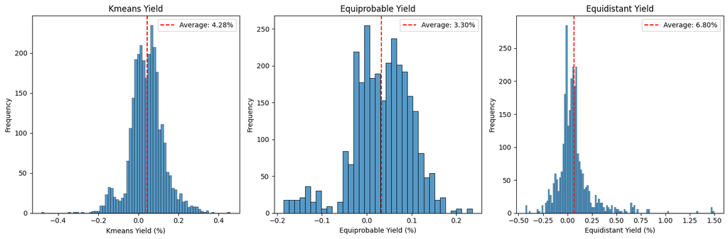

```python
# Calculate the mean of the yields
mean_cluster = yields_df['CLUSTER_YIELD'].mean() * 100
mean_equiprobable = yields_df['EQUIPROBABLE_YIELD'].mean() * 100
mean_equidistant = yields_df['EQUIDISTANT_YIELD'].mean() * 100

# Set the figure size
plt.figure(figsize=(15, 5))

# First plot: Histogram of CLUSTER_YIELD with a vertical line for the mean
plt.subplot(1, 3, 1)
sns.histplot(data=yields_df, x='CLUSTER_YIELD')
plt.axvline(mean_cluster / 100, color='red', linestyle='--', label=f'Average: {mean_cluster:.2f}%')
plt.title('Kmeans Yield')
plt.xlabel('Kmeans Yield (%)')
plt.ylabel('Frequency')
plt.legend()

# Second plot: Histogram of EQUIPROBABLE_YIELD with a vertical line for the mean
plt.subplot(1, 3, 2)
sns.histplot(data=yields_df, x='EQUIPROBABLE_YIELD')
plt.axvline(mean_equiprobable / 100, color='red', linestyle='--', label=f'Average: {mean_equiprobable:.2f}%')
plt.title('Equiprobable Yield')
plt.xlabel('Equiprobable Yield (%)')
plt.ylabel('Frequency')
plt.legend()

# Third plot: Histogram of EQUIDISTANT_YIELD with a vertical line for the mean
plt.subplot(1, 3, 3)
sns.histplot(data=yields_df, x='EQUIDISTANT_YIELD')
plt.axvline(mean_equidistant / 100, color='red', linestyle='--', label=f'Average: {mean_equidistant:.2f}%')
plt.title('Equidistant Yield')
plt.xlabel('Equidistant Yield (%)')
plt.ylabel('Frequency')
plt.legend()

plt.tight_layout()
plt.show()
```

```python
def pretty_table_print(df,column=''):

    table = PrettyTable()
    table.title = f'Yields variation by {column}'
    table.field_names = [column, 'Kmeans Yield', 'Kmeans Var.', 'Equiprobable Yield', 'Equiprobable Var.', 'Equidistant Yield', 'Equidistant Var.']
    for category in yields_df[column].unique():
        table.add_row([
            category,
            round(df[df[column] == category]['CLUSTER_YIELD'].mean() * 100, 2),
            round(df[df[column] == category]['CLUSTER_YIELD'].std() / abs(df[df[column] == category]['CLUSTER_YIELD'].mean()), 2),
            round(df[df[column] == category]['EQUIPROBABLE_YIELD'].mean() * 100, 2),
            round(df[df[column] == category]['EQUIPROBABLE_YIELD'].std() / abs(df[df[column] == category]['EQUIPROBABLE_YIELD'].mean()), 2),
            round(df[df[column] == category]['EQUIDISTANT_YIELD'].mean() * 100, 2),
            round(df[df[column] == category]['EQUIDISTANT_YIELD'].std() / abs(df[df[column] == category]['EQUIDISTANT_YIELD'].mean()), 2)
        ])
    print(table)

for col in ['DATA_TYPE', 'METRIC', 'MATRIX_TYPE', 'THRESHOLD']:
    pretty_table_print(df=yields_df, column=col)
    print()
```

```
+------------------------------------------------------------------------------------------------------------------------+
|                                             Yields variation by DATA_TYPE                                              |
+-----------+--------------+-------------+--------------------+-------------------+-------------------+------------------+
| DATA_TYPE | Kmeans Yield | Kmeans Var. | Equiprobable Yield | Equiprobable Var. | Equidistant Yield | Equidistant Var. |
+-----------+--------------+-------------+--------------------+-------------------+-------------------+------------------+
|    Open   |     4.45     |     1.85    |        3.24        |        2.05       |        6.85       |       2.72       |
|   Close   |     4.11     |     1.93    |        3.34        |        2.08       |        6.17       |       2.92       |
|    Low    |     4.22     |     2.16    |        3.21        |        2.09       |        6.93       |       2.99       |
|    High   |     3.88     |     2.14    |        3.13        |        2.11       |        7.14       |       2.7        |
| Adj Close |     4.73     |     1.69    |        3.58        |        1.82       |        6.93       |       2.72       |
+-----------+--------------+-------------+--------------------+-------------------+-------------------+------------------+

+--------------------------------------------------------------------------------------------------------------------------------+
|                                                   Yields variation by METRIC                                                   |
+-------------------+--------------+-------------+--------------------+-------------------+-------------------+------------------+
|       METRIC      | Kmeans Yield | Kmeans Var. | Equiprobable Yield | Equiprobable Var. | Equidistant Yield | Equidistant Var. |
+-------------------+--------------+-------------+--------------------+-------------------+-------------------+------------------+
|       return      |     4.06     |     1.74    |        3.06        |        2.26       |        9.28       |       2.01       |
|        risk       |     4.57     |     1.8     |        3.39        |        1.65       |        6.85       |       2.78       |
|    sharpe_ratio   |     4.24     |     1.82    |        3.26        |        2.1        |        8.0        |       3.36       |
| information_ratio |     4.67     |     1.79    |        3.06        |        2.26       |        6.94       |       2.61       |
|   sortino_ratio   |     3.88     |     2.61    |        3.36        |        2.05       |        4.28       |       2.99       |
|    calmar_ratio   |     4.25     |     1.91    |        3.65        |        1.87       |        5.46       |       2.93       |
+-------------------+--------------+-------------+--------------------+-------------------+-------------------+------------------+

+--------------------------------------------------------------------------------------------------------------------------+
|                                             Yields variation by MATRIX_TYPE                                              |
+-------------+--------------+-------------+--------------------+-------------------+-------------------+------------------+
| MATRIX_TYPE | Kmeans Yield | Kmeans Var. | Equiprobable Yield | Equiprobable Var. | Equidistant Yield | Equidistant Var. |
+-------------+--------------+-------------+--------------------+-------------------+-------------------+------------------+
| correlation |     4.24     |     1.9     |        3.3         |        2.03       |        6.8        |       2.81       |
|  covariance |     4.25     |     2.02    |        3.3         |        2.03       |        6.8        |       2.81       |
|    normal   |     4.35     |     1.92    |        3.3         |        2.03       |        6.8        |       2.81       |
+-------------+--------------+-------------+--------------------+-------------------+-------------------+------------------+

+------------------------------------------------------------------------------------------------------------------------+
|                                             Yields variation by THRESHOLD                                              |
+-----------+--------------+-------------+--------------------+-------------------+-------------------+------------------+
| THRESHOLD | Kmeans Yield | Kmeans Var. | Equiprobable Yield | Equiprobable Var. | Equidistant Yield | Equidistant Var. |
+-----------+--------------+-------------+--------------------+-------------------+-------------------+------------------+
|    min    |     3.66     |     1.91    |        3.87        |        1.71       |       10.09       |       2.56       |
|    max    |     4.9      |     1.93    |        2.73        |        2.45       |        3.51       |       1.86       |
+-----------+--------------+-------------+--------------------+-------------------+-------------------+------------------+
```

### Observations of Yield Variations

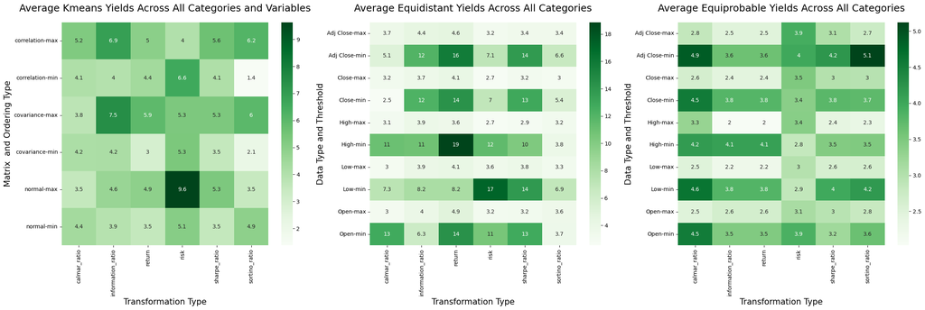

```python
# pivot tables
pivot_table_adj_close = pd.pivot_table(
    data=yields_df[yields_df['DATA_TYPE'] == 'Adj Close'],
    values='CLUSTER_YIELD',
    columns='METRIC',
    index=['MATRIX_TYPE', 'THRESHOLD'],
    aggfunc='mean'
)

pivot_table_equidistant = pd.pivot_table(
    data=yields_df,
    values='EQUIDISTANT_YIELD',
    columns='METRIC',
    index=['DATA_TYPE', 'THRESHOLD'],
    aggfunc='mean'
)

pivot_table_equiprobable = pd.pivot_table(
    data=yields_df,
    values='EQUIPROBABLE_YIELD',
    columns='METRIC',
    index=['DATA_TYPE', 'THRESHOLD'],
    aggfunc='mean'
)

# Graphs
fig, axes = plt.subplots(1, 3, figsize=(24, 8))

# Kmeans Yields
sns.heatmap(pivot_table_adj_close * 100, cmap='Greens', annot=True, ax=axes[0])
axes[0].set_xlabel('Transformation Type', fontsize=15)
axes[0].set_ylabel('Matrix  and Ordering Type', fontsize=15)
axes[0].set_title('Average Kmeans Yields Across All Categories and Variables', fontsize=18, pad=20)

# Equidistant Yields
sns.heatmap(pivot_table_equidistant * 100, cmap='Greens', annot=True, ax=axes[1])
axes[1].set_xlabel('Transformation Type', fontsize=15)
axes[1].set_ylabel('Data Type and Threshold', fontsize=15)
axes[1].set_title('Average Equidistant Yields Across All Categories', fontsize=18, pad=20)

# Equiprobable Yields
sns.heatmap(pivot_table_equiprobable * 100, cmap='Greens', annot=True, ax=axes[2])
axes[2].set_xlabel('Transformation Type', fontsize=15)
axes[2].set_ylabel('Data Type and Threshold', fontsize=15)
axes[2].set_title('Average Equiprobable Yields Across All Categories', fontsize=18, pad=20)

plt.tight_layout()
plt.show()
```

### Observations

- In the first graph, we analyzed the results of the K-means segmentation by grouping yield data based on matrix type and ordering, compared to transformation type, while considering only adjusted closing prices. From this, we observe that max ordering, along with covariance and correlation matrices, and the risk ratio are the most consistent indicators. By "consistent," I refer to how reliably they perform when combined with other metrics.
- In the second graph, we focused on equidistant yields, grouping values by type, ordering, and transformation. Here, min ordering, as well as the return and Sharpe ratios, stand out. No significant differences were observed concerning the price type.
- In the third graph, we examined equiprobable yields, grouping values by type, ordering, and transformation. Again, min ordering stands out, along with adjusted closing prices and the Calmar ratio.

### Conclusions

For decision-making, it is crucial for the fund manager to decide whether to prioritize dynamic or static transformations. For dynamic transformations, I recommend using the covariance matrix, max ordering, and the risk ratio. For static transformations, I would suggest opting for the equiprobable distribution, adjusted closing prices, min ordering, and the Calmar ratio.

That said, these results should undergo more extensive testing before deploying an algorithm, but they provide a strong foundation for further analysis.